# ggplot Cheatsheet - basics

## 4.2 Facets

Facets for ggplot in R

[ggplot2 - Lay out panels in a grid](https://ggplot2.tidyverse.org/reference/facet_grid.html)

[Setting individual axis limits with facet wrap and scales free](https://stackoverflow.com/questions/18046051/setting-individual-axis-limits-with-facet-wrap-and-scales-free-in-ggplot2)

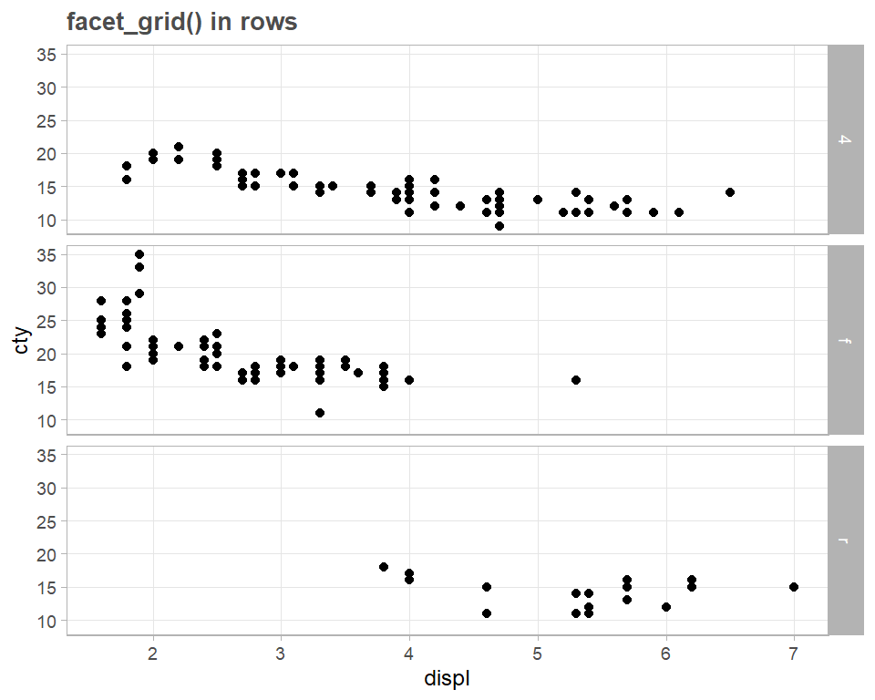

```r
p <- ggplot(mpg, aes(displ, cty)) + geom_point()

# Use vars() to supply variables from the dataset:
p + facet_grid(rows=vars(drv)) +
  labs(title="facet_grid() in rows")
```

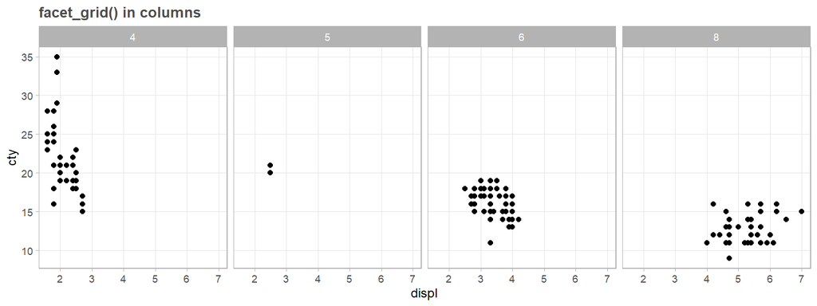

```r
p + facet_grid(cols=vars(cyl)) +
  labs(title="facet_grid() in columns")
```

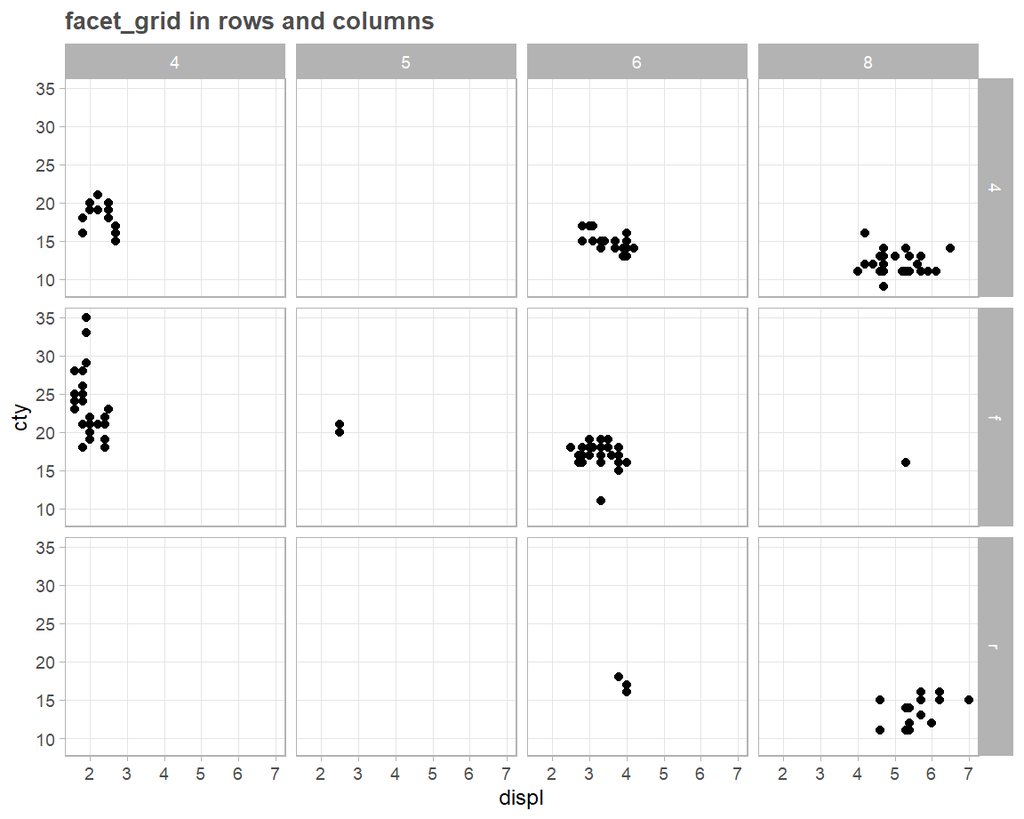

```r
p + facet_grid(drv ~ cyl) +
  labs(title="facet_grid in rows and columns")
```

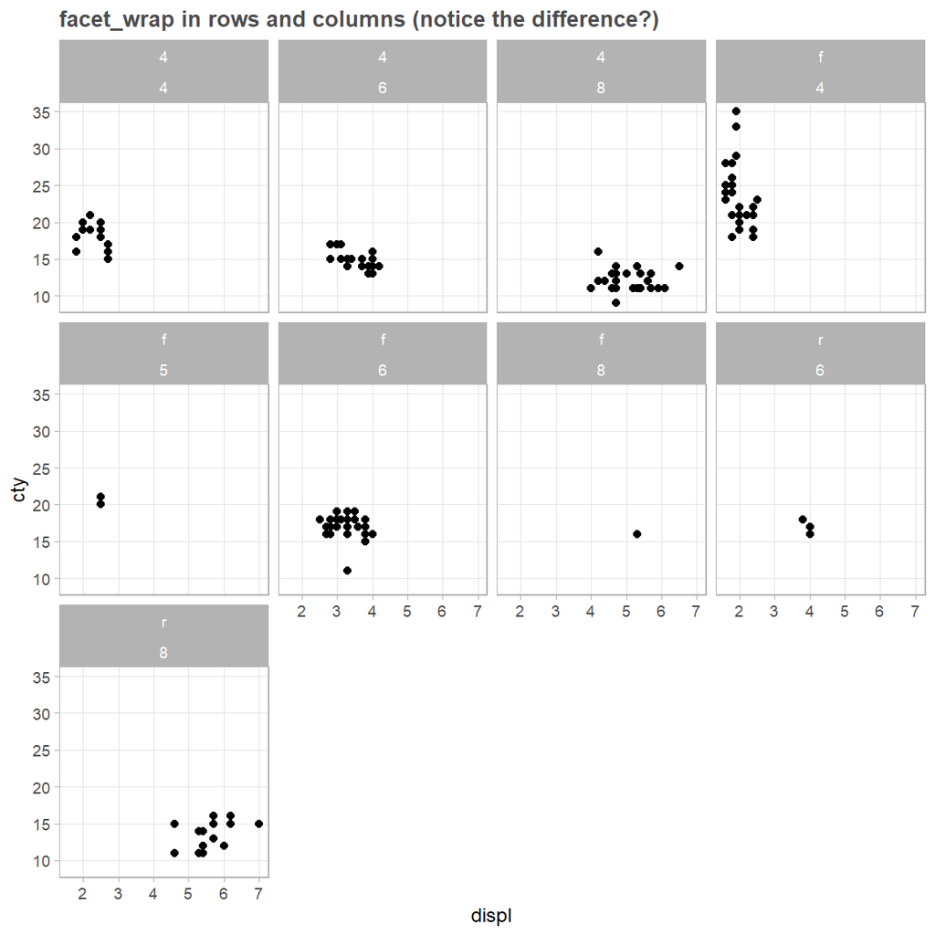

```r
p + facet_wrap(drv~cyl, ncol=4) +
  labs(title="facet_wrap in rows and columns (notice the difference?)")
```

To change plot order of facet grid, change the order of variable levels with `factor()`. More on this under **ORDERING**.

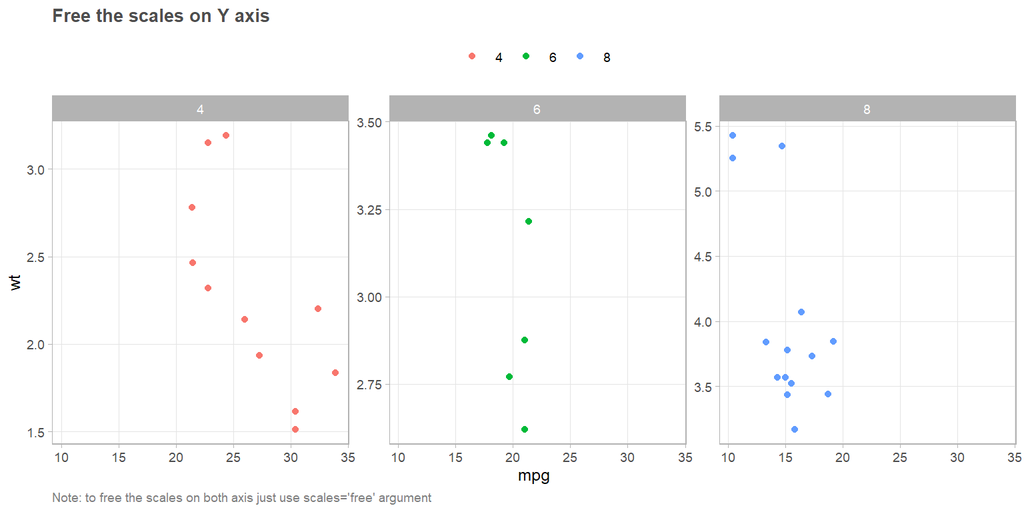

```r
ggplot(mtcars, aes(mpg, wt, colour=factor(cyl))) +
  geom_point() +
  facet_wrap(~cyl, scales="free_y") +
  theme(legend.position="top") +
  labs(title="Free the scales on Y axis",
       caption="Note: to free the scales on both axis just use scales='free' argument")
```

I would like to have the x-axis labels show up on each facet. How?  
[stackoverflow](https://stackoverflow.com/questions/17661052/force-x-axis-text-on-for-all-facets-of-a-facet-grid-plot)

## 4.3 Alternative: Cowplot

Cowplot provides various features that help with creating publication-quality figures, such as a set of themes, functions to align plots and arrange them into complex compound figures, and functions that make it easy to annotate plots and or mix plots with images.

[Vignettes](https://wilkelab.org/cowplot/articles/index.html)

[Documentation](https://wilkelab.org/cowplot/reference/index.html)

The cowplot package provides the function `plot_grid()` to arrange plots into a grid and label them.

The `plot_grid()` is built on top of a generic drawing layer that also allows you to capture plots as images and then draw with them or on top of them.

# 5 ORDERING

[Reorder items to appear on your plots with FACTORS](https://r-graph-gallery.com/267-reorder-a-variable-in-ggplot2.html)

Reordering groups in a ggplot2 chart can be a struggle.  
This is because ggplot2 takes into account the order of the factor levels, not the order you observe in your data frame. You can sort your input data frame with `sort()` or `arrange()`, and it will not have any impact on your ggplot2 output.

Enter `forcats`. The `forcats` library is a library from the tidyverse especially made to handle factors in R. It provides a suite of useful tools that solve common problems with factors.

The `fct_reorder()` function allows you to reorder the factor following the value of another column.

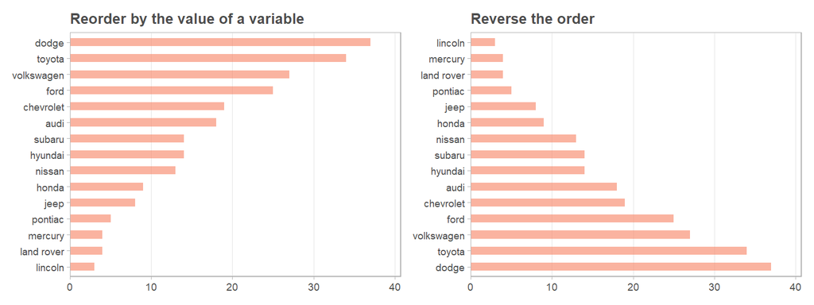

```r
library(forcats)

# Reorder following the value of another column:
p1 <- mpg |> group_by(manufacturer) |> tally(name="qtd") |>
  mutate(manufacturer=fct_reorder(manufacturer, qtd)) |>
  ggplot( aes(x=manufacturer, y=qtd)) +
  geom_col(fill="#f68060", alpha=.6, width=.5) +
  scale_y_continuous(expand=expansion(mult=c(0,.1))) +
  theme(panel.grid.major.y=element_blank()) +
  labs(title="Reorder by the value of a variable", x=NULL, y=NULL) +
  coord_flip()

# Reverse side
p2 <- mpg |> group_by(manufacturer) |> tally(name="qtd") |>
  mutate(manufacturer=fct_reorder(manufacturer, desc(qtd))) |>
  ggplot( aes(x=manufacturer, y=qtd)) +
  geom_col(fill="#f68060", alpha=.6, width=.5) +
  scale_y_continuous(expand=expansion(mult=c(0,.1))) +
  theme(panel.grid.major.y=element_blank()) +
  labs(title="Reverse the order", x=NULL, y=NULL) +
  coord_flip()

p1 + p2
```

If you have several values per level of your factor, you can specify which function to apply to aggregate and determine the order. The default is to use the median, but you can use the number of data points per group to make the classification:

[figure not shown]

```r
# Using sum
p1 <- mpg |>
  mutate(class=fct_reorder(class, hwy, .fun='sum')) |>
  ggplot( aes(x=reorder(class, hwy), y=hwy, fill=class)) +
  geom_boxplot() +
  labs(title="Using sum of the hwy by class", x="class") +
  coord_flip()

# Using number of observation per group
p2 <- mpg |>
  mutate(class=fct_reorder(class, hwy, .fun='length' )) |>
  ggplot( aes(x=class, y=hwy, fill=class)) +
  geom_boxplot() +
  labs(title="Using number of obs by class", x=NULL) +
  coord_flip()

p1 + p2 & theme(legend.position="none", panel.border=element_rect(fill=NA))
```

Here we use the mpg data and summarize the number of car model variants per manufacturer. We also adjust the manufacturer labels and order them as they should appear in the final plot. We want to order the bars based on their value in our visualization.

Keep in mind that we have reversed the ordering since `{ggplot2}` plots factors from bottom to top when they are mapped to y.

```r
mpg_sum <- mpg |>
  filter(year == 2008) |>

  mutate(
    manufacturer=str_to_title(manufacturer),
    #  group all manufacturers together that do not belong to the top 10
    manufacturer=forcats::fct_lump(manufacturer, n=9) # Lump puts n>9 em "Other"
  ) %>%

  # add counts (data is automatically sorted in descending order)
  count(manufacturer, sort=TRUE) %>%

  mutate(
    # first order by appearance with `fct_inorder()`
    # reverse order so that the bar with the highest value is on top
    manufacturer=forcats::fct_rev(forcats::fct_inorder(manufacturer)),
    # move the category “Other” to the end (as the first level)
    manufacturer=forcats::fct_relevel(manufacturer, "Other", after=0)
  ) |>
  arrange(manufacturer)

mpg_sum
```

```
## # A tibble: 10 × 2
##    manufacturer     n
##    <fct>        <int>
##  1 Other           17
##  2 Nissan           7
##  3 Subaru           8
##  4 Hyundai          8
##  5 Audi             9
##  6 Ford            10
##  7 Volkswagen      11
##  8 Chevrolet       12
##  9 Toyota          14
## 10 Dodge           21
```

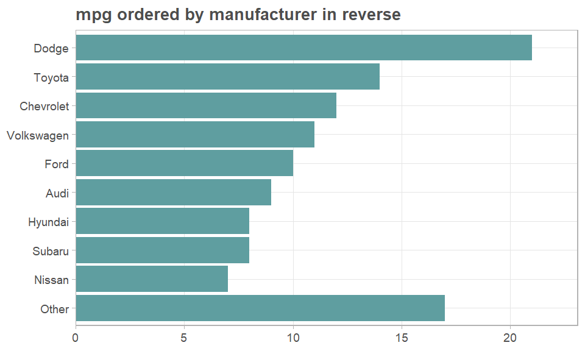

```r
ggplot(mpg_sum, aes(x=n, y=manufacturer)) +
  geom_col(fill="cadetblue") +
  scale_x_continuous(expand=expansion(mult=c(0,.1))) +
  labs(title="mpg ordered by manufacturer in reverse", y=NULL, x=NULL)
```

# 6 OTHER ELEMENTS

## 6.1 Titles, captions

Customize plot and axis titles using labs.

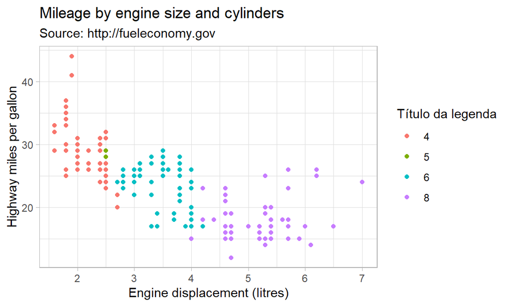

```r
ggplot(mpg, aes(displ, hwy)) +
  geom_point(aes(colour=factor(cyl))) +
  labs(
    x="Engine displacement (litres)",
    y="Highway miles per gallon",
    color="Título da legenda", #TÍTULO DA LEGENDA ASSUME NOME DADO Á DIMENSÃO DOS ITENS DA LEGENDA
    title="Mileage by engine size and cylinders",
    subtitle="Source: http://fueleconomy.gov"
  ) +
  theme_light()
```

Note that setting `labs(x=NULL)` removes the label and its space.

The values supplied to `labs()` are typically text strings, with `\n` used to specify line breaks, but you can also supply mathematical expressions wrapped in `quote()`.

The rules by which these expressions are interpreted can be found by typing `?plotmath`.

```r
values <- seq(from=-2, to=2, by=.01)
df <- data.frame(x=values, y=values ^ 3)
```

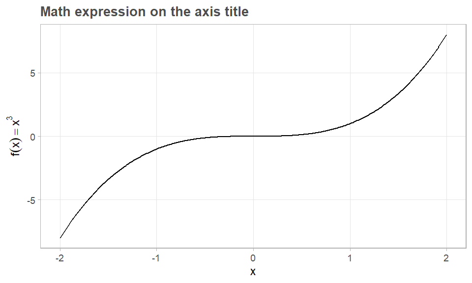

```r
ggplot(df, aes(x, y)) +
  geom_path() +
  labs(y=quote(f(x) == x^3),
       title="Math expression on the axis title")
```

## 6.2 Number formatting

[Format numbers with scale package!](https://bookdown.org/Maxine/ggplot2-maps/posts/2019-11-27-using-scales-package-to-modify-ggplot2-scale/)

The [scales package](https://www.rdocumentation.org/packages/scales) provides the internal scaling infrastructure used by ggplot2, and gives you tools to override the default breaks, labels, transformations and palettes. When you type `scales::label_` autocomplete will provide you with a list of labelling functions to jog your memory.

[Short introduction to `scales`](https://scales.r-lib.org/)

## 6.3 Legends

**Customize legend labels:** You can use the `labels` argument in a scale to customize labeling. You can provide a function or a character vector to the labels argument.

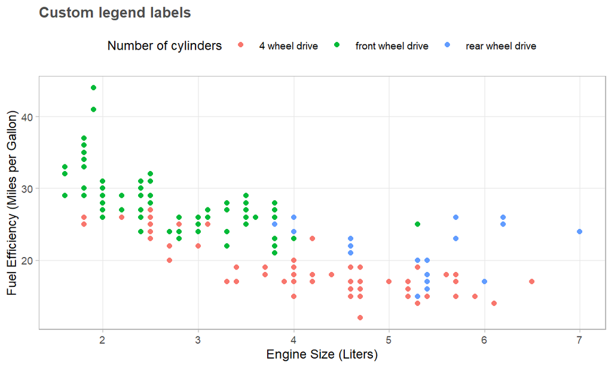

```r
ggplot(data=mpg) +
  geom_point(mapping=aes(x=displ, y=hwy, color=drv)) +
  scale_colour_discrete(
    labels=c("4"="4 wheel drive",
               "f"="front wheel drive",
               "r"="rear wheel drive")
  ) +
  labs(
    title="Custom legend labels",
    x="Engine Size (Liters)",
    y="Fuel Efficiency (Miles per Gallon)",
    colour="Number of cylinders"
  ) +
  theme(legend.title=element_text(),
        axis.title=element_text())
```

**Control legend layout:** You can control how many rows or columns your legend layout will be with `guides(colour=guide_legend(nrow=1))`

**Reverse legend order:** You can reverse the order of items in the legend guide without affecting the plot. If you want to reverse the order of the plot itself (including the legend), then check out **ORDERING** section.

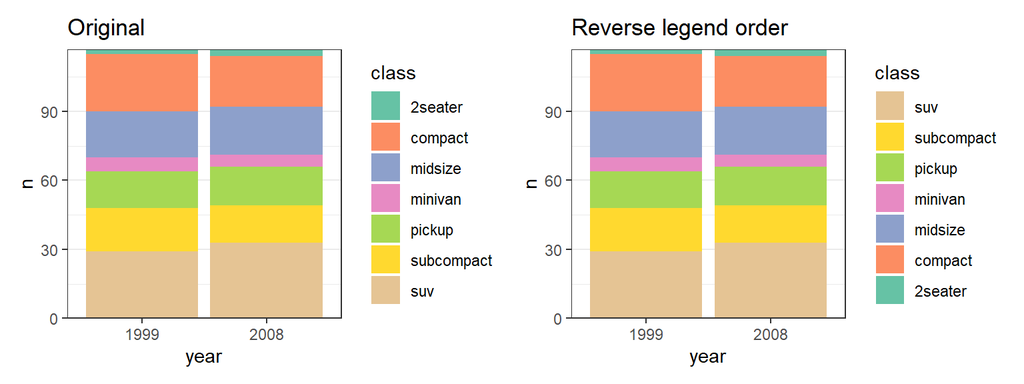

```r
p1 <- mpg |> group_by(class, year=as.factor(year)) |>
  tally() |>
  ggplot() +
  geom_bar(aes(x=year, y=n, fill=class),stat="identity") +
  scale_fill_brewer(palette="Set2") +
  scale_y_continuous(expand=c(0,0), labels=scales::number) +
  theme_bw() +
  labs(title="Original")

p2 <- mpg |> group_by(class, year=as.factor(year)) |>
  tally() |>
  ggplot() +
  geom_bar(aes(x=year, y=n, fill=class),stat="identity") +
  scale_y_continuous(expand=c(0,0), labels=scales::number) +
  # reverse legend order - can be used on any scale_fill_* or scale_color_*
  scale_fill_brewer(palette="Set2", guide=guide_legend(reverse=TRUE)) +
  theme_bw() +
  labs(title="Reverse legend order")

p1 + p2
```

You can create a single legend for separate geoms. In `{ggplot}`, legends are automatically created for mapped aesthetics. You can add such mappings as follows:

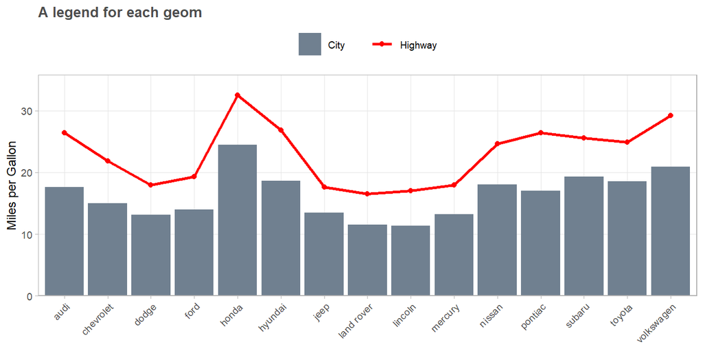

```r
mpg |>
  summarise(hwy=mean(hwy), cty=mean(cty), .by=manufacturer) |>
  ggplot(aes(x=manufacturer)) +
  # specify color for line/ fill for bar inside aes(); you can assign a label for the legend
  geom_line(aes(y=hwy, group=1, color="Highway"), size=1) +
  geom_point(aes(y=hwy, color="Highway")) +
  geom_col( aes(y=cty, fill="City")) +
  # then assign the desired color to the labels specified above
  scale_color_manual(name="", values=c("Highway"="red")) +
  scale_fill_manual(name="", values=c("City"="slategray")) +
  scale_y_continuous(expand=expansion(mult=c(0,.1))) +
  scale_x_discrete(guide=guide_axis(angle=45)) +
  labs(
    x=NULL,
    y="Miles per Gallon" ,
    title="A legend for each geom"
  )
```

[All legend settings](https://www.datanovia.com/en/blog/ggplot-legend-title-position-and-labels/)

```
# Legend title and text labels
#:::::::::::::::::::::::::::::::::::::::::::::::::::::::::::
legend.title=element_text(color, size, face), # Title font color size and face
legend.title.align=NULL, # Title alignment. Number from 0 (left) to 1 (right)
legend.text=element_text(color, size, face), # Text label font color size and face
legend.text.align=NULL, # Text label alignment. Number from 0 (left) to 1 (right)

# Legend position, margin and background
#:::::::::::::::::::::::::::::::::::::::::::::::::::::::::::
legend.position="none", # Legend position: right, left, bottom, top, none
legend.margin=margin(0.2, 0.2, 0.2, 0.2, "cm"), # Margin around each legend
legend.background=element_rect(fill, color, size, linetype), # Legend background

# Legend direction and justification
#:::::::::::::::::::::::::::::::::::::::::::::::::::::::::::
legend.direction=NULL, # Layout of items in legends ("horizontal" or "vertical")
legend.justification="center", # Position legend ("center" or 2-element num vector)

# Background underneath legend keys
#:::::::::::::::::::::::::::::::::::::::::::::::::::::::::::
legend.key=element_rect(fill, color),  # Key background
legend.key.size=unit(1.2, "lines"),    # key size (unit)
legend.key.height=NULL,                # key height (unit)
legend.key.width=NULL,                 # key width (unit)

# Spacing between legends.
#:::::::::::::::::::::::::::::::::::::::::::::::::::::::::::
legend.spacing=unit(0.4, "cm"),
legend.spacing.x=NULL,                 # Horizontal spacing
legend.spacing.y=NULL,                 # Vertical spacing

# Legend box
#:::::::::::::::::::::::::::::::::::::::::::::::::::::::::::
legend.box=NULL, # Arrangement of multiple legends ("horizontal" or "vertical")
legend.box.margin=margin(0, 0, 0, 0, "cm"), # Margins around the full legend area
legend.box.background=element_blank(), # Background of legend area: element_rect()
legend.box.spacing=unit(0.4, "cm") # Space btwn the plot area and the legend box
```

## 6.4 Axis scales

[Numeric position scales](https://ggplot2-book.org/scale-position.html#numeric-position-scales): set limits, zoom in, breaks, labels and transformations.

**Zooming in**

It is possible to narrow the default scale limits, but care is required: when you truncate the scale limits, some data points will fall outside the boundaries you set, and ggplot2 has to make a decision about what to do with these data points. The default behaviour in ggplot2 is to convert any data values outside the scale limits to `NA`. This means that changing the limits of a scale is not always the same as visually zooming in to a region of the plot. If your goal is to zoom in on part of the plot, it is usually better to use the `xlim` and `ylim` arguments of `coord_cartesian()`:

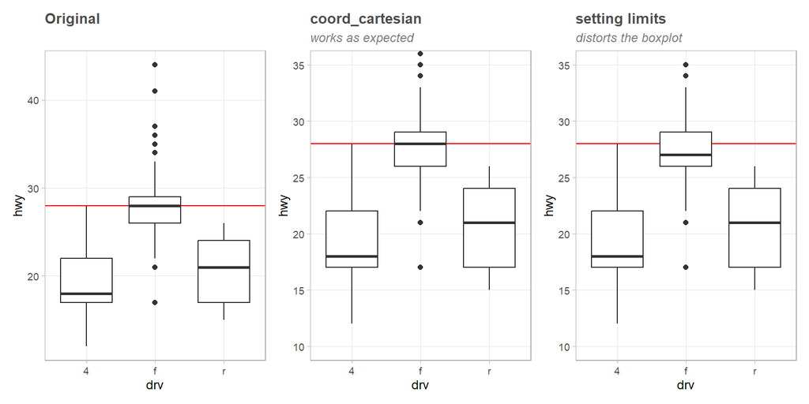

```r
plot <- ggplot(mpg, aes(drv, hwy)) +
  geom_hline(yintercept=28, colour="red") +
  geom_boxplot()

p1 <- plot + labs(title="Original")

p2 <- plot + labs(title="coord_cartesian", subtitle="works as expected") +
  coord_cartesian(ylim=c(10, 35))

p3 <- plot + labs(title="setting limits", subtitle="distorts the boxplot") +
  ylim(10, 35)

p1 + p2 + p3
```

**Breaks**

Setting the locations of the axis tick marks is a common task. Axis tick marks and legend tick marks are both special cases of “scale breaks”, and can be modified using the `breaks` argument to the scale function.

To set breaks manually, pass a vector of data values to breaks, or set `breaks=NULL` to remove the breaks and the corresponding tick marks entirely. In the plot below, removing the y-axis breaks also removes the corresponding grid lines.

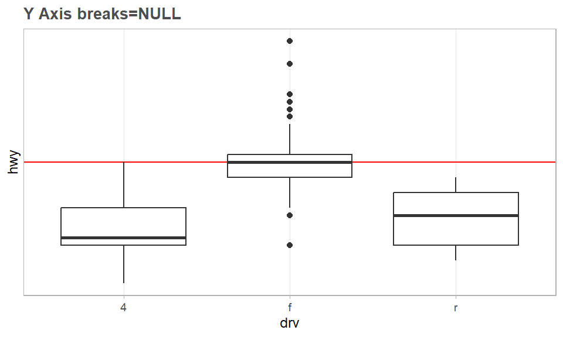

```r
plot + scale_y_continuous(breaks=NULL) + labs(title="Y Axis breaks=NULL")
```

Another approach is specifying a fixed width that defines the spacing between breaks. The `breaks_width()` function is used for this. The first example below shows how to fix the width at a specific value; the second example illustrates the use of the offset argument that shifts all the breaks by a specified amount:

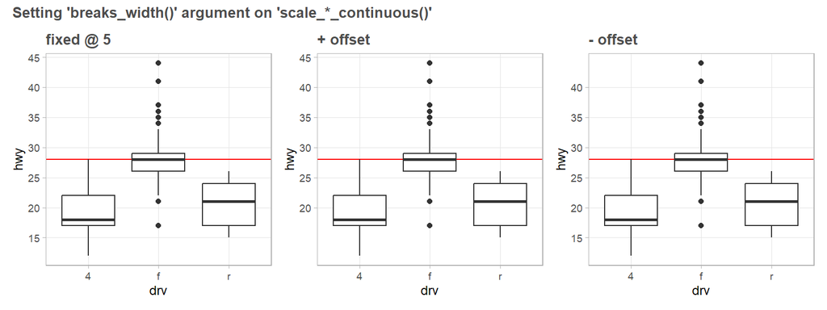

```r
p1 <- plot + scale_y_continuous(breaks=scales::breaks_width(5)) +
  labs(title="fixed @ 5")

p2 <- plot + scale_y_continuous(breaks=scales::breaks_width(5, offset(10))) +
  labs(title="+ offset")

p3 <- plot + scale_y_continuous(breaks=scales::breaks_width(5, offset(-10))) +
  labs(title="- offset")

p1 + p2 + p3 + plot_annotation(title="Setting 'breaks_width()' argument on 'scale_*_continuous()'")
```

### 6.4.1 Time Series

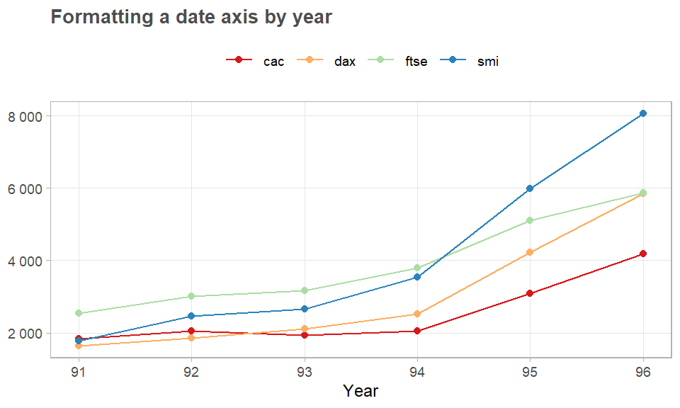

```r
ts.dia <- as_tibble(EuStockMarkets) |> cbind(
  DATE=seq.Date(as.Date("1991-1-1"), by="days", length.out=1860)
) |>
  rename_with(tolower) |>
  pivot_longer(dax:ftse)

ts.dia |>
  group_by(ano=make_date(year(date),1,1), name) |>
  summarise(value=mean(value), .groups="drop") |>
  ggplot(aes(x=ano, y=value, group=name, color=name)) +
  geom_line() + geom_point() +
  scale_color_brewer(palette="Spectral") +
  scale_y_continuous(labels=scales::number) +
  scale_x_date(
    # labels=scales::label_date_short(), # formata texto de x-axis
    labels=scales::label_date("%y"),
    date_breaks="1 year", # “sec", "min", "hour", "day", "week", "month", "year"
    # expand=c(0.01,0.01), # respiro nas laterais das barras
  ) +
  labs(title="Formatting a date axis by year", x="Year", y=NULL)
```

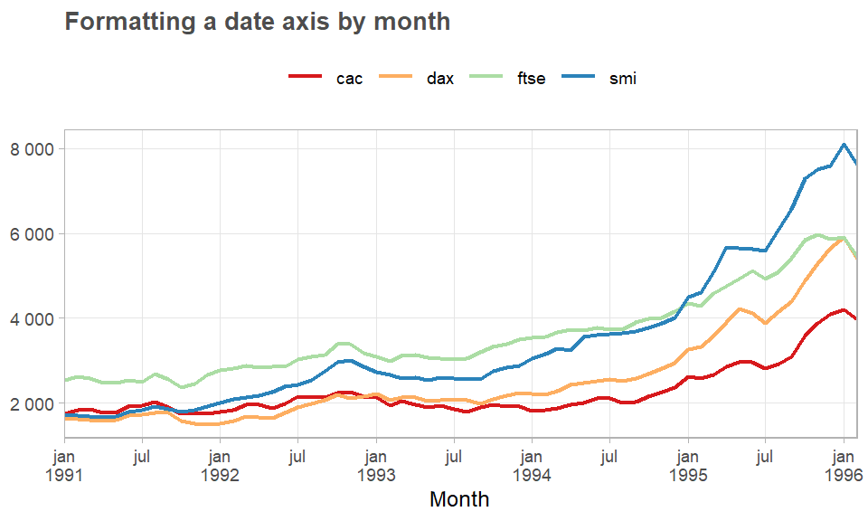

```r
ts.dia |>
  group_by(mes=make_date(year(date),month(date),1), name) |>
  summarise(value=mean(value), .groups="drop") |>
  ggplot(aes(x=mes, y=value, group=name, color=name)) +
  geom_line(size=.8) +
  scale_color_brewer(palette="Spectral") +
  scale_y_continuous(labels=scales::number) +
  scale_x_date(
    labels=scales::label_date_short(), # formata texto de x-axis
    date_breaks="6 months",
    # breaks=seq.Date(min(ts.dia$date), max(ts.dia$date),by="6 months")
    expand=c(0,0), # respiro nas laterais das barras
  ) +
  labs(title="Formatting a date axis by month", x="Month", y=NULL)
```

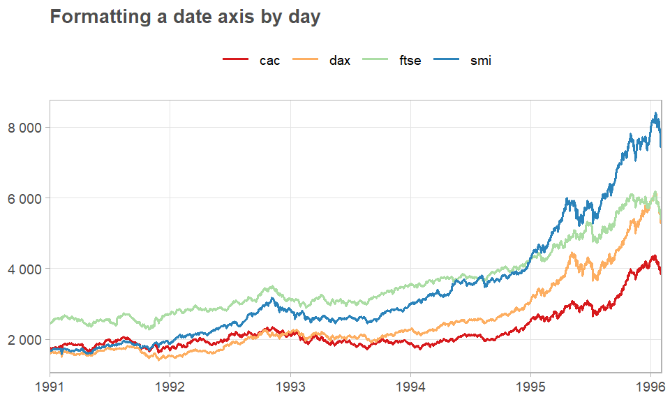

```r
ts.dia |>
  ggplot(aes(x=date, y=value, group=name, color=name)) +
  geom_line(size=.6) +
  scale_color_brewer(palette="Spectral") +
  scale_y_continuous(labels=scales::number) +
  scale_x_date(
    labels=scales::label_date_short(), # formata texto de x-axis
    # date_breaks="6 months",
    expand=c(0,0), # respiro nas laterais das barras
  ) +
  labs(title="Formatting a date axis by day", x=NULL, y=NULL)
```

[Scale transformations](https://ggplot2-book.org/scale-position.html#scale-transformation)

[Rdocumentation on scale_*_continuous()](https://www.rdocumentation.org/packages/ggplot2/versions/1.0.0/topics/scale_x_continuous)

[Tidyverse documentation on scale_*_continuous()](https://ggplot2.tidyverse.org/reference/scale_continuous.html)

To control the extra breathing space at either end of the axis:

`scale_y_continuous(expand=expansion(mult=c(0, .1)))` will extend only the top end of your Y-axis by 10%

`scale_y_continuous(expand=expansion(add=c(0, 5)))` will extend that end by a fixed amount of 5 units of space.

To figure out how to control date scales check out AXIS SCALES > Time series section of this document

## 6.5 Axis labels

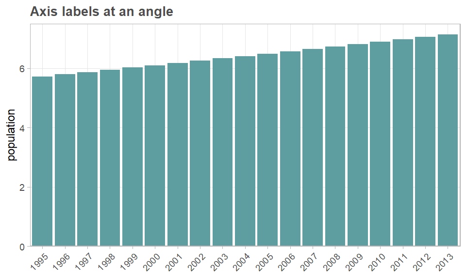

```r
population |>
  ggplot(aes(x=as.factor(year), y=population)) +
  geom_col(fill="cadetblue") +
  scale_y_continuous(labels=scales::label_number(scale=1/1e9),
                     expand=expansion(mult=c(0,0.05))) +
  scale_x_discrete(expand=expansion(mult=c(0.03,0.03)), guide=guide_axis(angle=45)) +
  theme(panel.border=element_rect(fill=NA)) +
  labs(x=NULL, title="Axis labels at an angle")
```

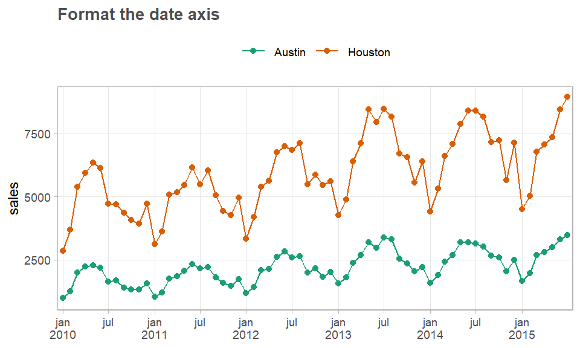

```r
txhousing |> mutate(date=make_date(year,month,1)) |>
  filter(city %in% c("Austin", "Houston")) |>
  na.omit() |>
  ggplot(aes(x=date, y=sales, group=city, color=city)) +
  geom_line() + geom_point() +
  scale_color_brewer(palette="Dark2") +
  scale_x_date(
    breaks=seq(as_date("2010-01-01"), as_date("2015-01-01"), by="6 months"),
    labels=scales::label_date_short(), # formata texto de x-axis
    limits=c(as_date("2010-01-01"), NA),
    # date_breaks="3 months", # “sec", "min", "hour", "day", "week", "month", "year"
    # labels=scales::label_date("%y"),
    expand=c(0.01,0.01), # respiro nas laterais das barras
  ) +
  labs(x=NULL, title="Format the date axis")
```

## 6.6 Data labels

[geom_text() documentation](https://rdrr.io/cran/ggplot2/man/geom_text.html)  
[geom_text() on tidyverse.org](https://ggplot2.tidyverse.org/reference/geom_text.html)  
[What is the width argument in position_dodge()?](https://stackoverflow.com/questions/34889766/what-is-the-width-argument-in-position-dodge)

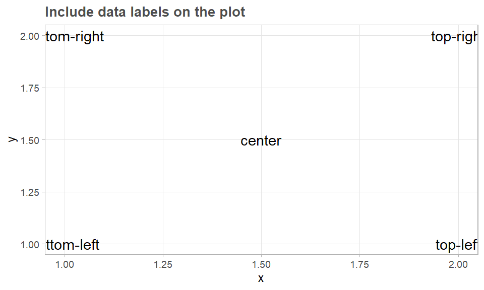

```r
df <- data.frame(
  x=c(1, 1, 2, 2, 1.5),
  y=c(1, 2, 1, 2, 1.5),
  text=c("bottom-left", "bottom-right", "top-left", "top-right", "center")
)


ggplot(df, aes(x, y)) +
  geom_text(aes(label=text)) +
  labs(title="Include data labels on the plot")
```

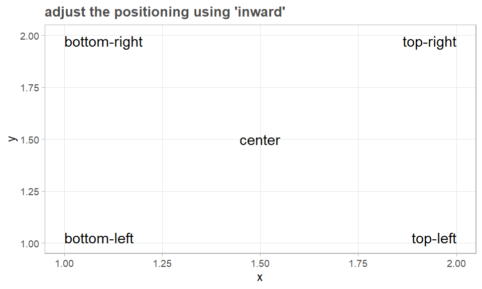

```r
ggplot(df, aes(x, y)) +
  geom_text(aes(label=text), vjust="inward", hjust="inward") +
  labs(title="adjust the positioning using 'inward'")
```

### 6.6.1 Fixed label position

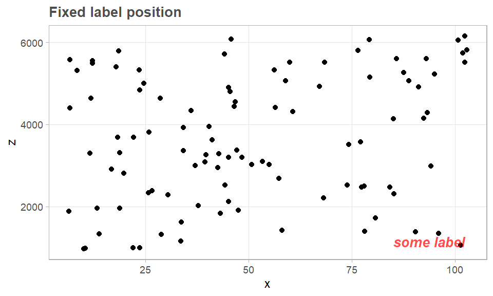

```r
data.frame(
  x = runif(100, min = sample(0:50, 1), max = sample(50:1000, 1)),
  y = runif(100, min = sample(0:1000, 1), max = sample(1000:10000, 1))
) |>
  mutate(z = x + y) |>
  ggplot(aes(x = x, y = z)) +
  geom_point() +
  annotation_custom(
    grid::textGrob(label = "some label",
                   x=.95, y=.1, vjust=1, hjust=1,
                   gp = grid::gpar(col="red", alpha=.7, fontsize=10, fontface="bold.italic"))
  ) +
  labs(title = "Fixed label position")
```

You can re-run this and observe the plot label stay fixed even as the x/y axis ranges change significantly.

### 6.6.2 Bar chart labels

You find several examples in `?geom_text` on how to position geom_text on dodged or stacked bars.

```r
df <- data.frame(
  x=factor(c(1, 1, 2, 2)),
  y=c(1, 3, 2, 1),
  grp=c("a", "b", "a", "b")
)
```

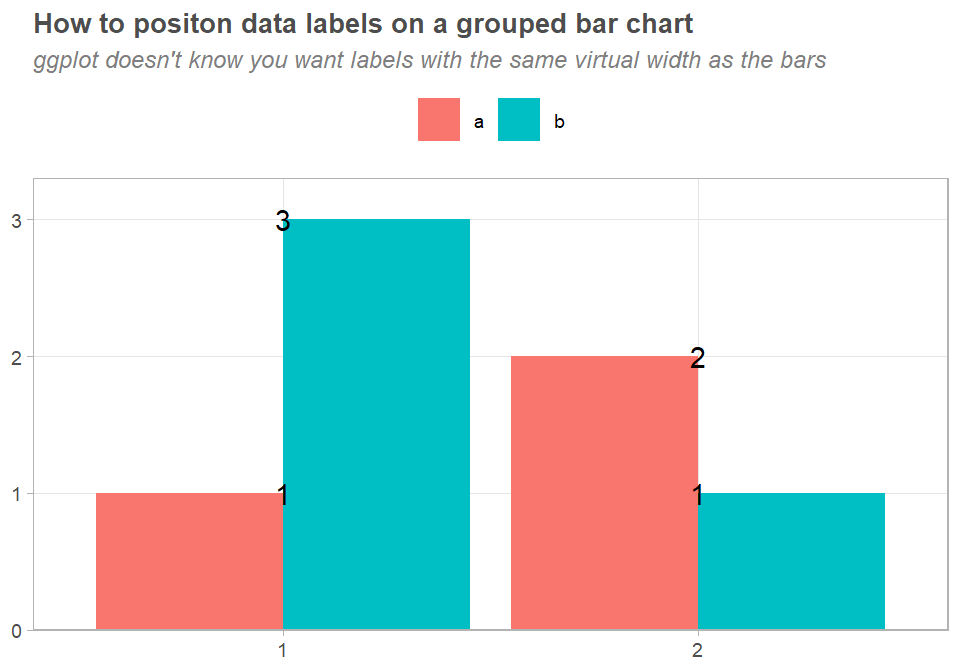

```r
ggplot(data=df, aes(x, y, group=grp)) +
  geom_col(aes(fill=grp), position=position_dodge()) +
  geom_text(aes(label=y), position=position_dodge()) +
  scale_y_continuous(expand=expansion(mult=c(0,.1))) +
  theme(legend.position="top") +
  labs(title="How to positon data labels on a grouped bar chart",
       subtitle="ggplot doesn't know you want labels with the same virtual width as the bars",
       x=NULL, y=NULL)
```

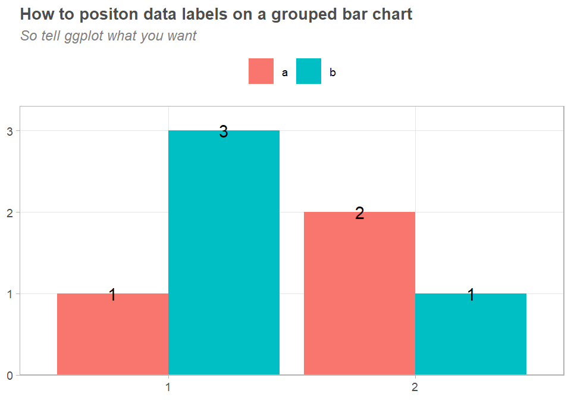

```r
ggplot(data=df, aes(x, y, group=grp)) +
  geom_col(aes(fill=grp), position=position_dodge()) +
  geom_text(aes(label=y), position=position_dodge(0.9)) +
  scale_y_continuous(expand=expansion(mult=c(0,.1))) +
  theme(legend.position="top") +
  labs(title="How to positon data labels on a grouped bar chart",
       subtitle="So tell ggplot what you want",
       x=NULL, y=NULL)
```

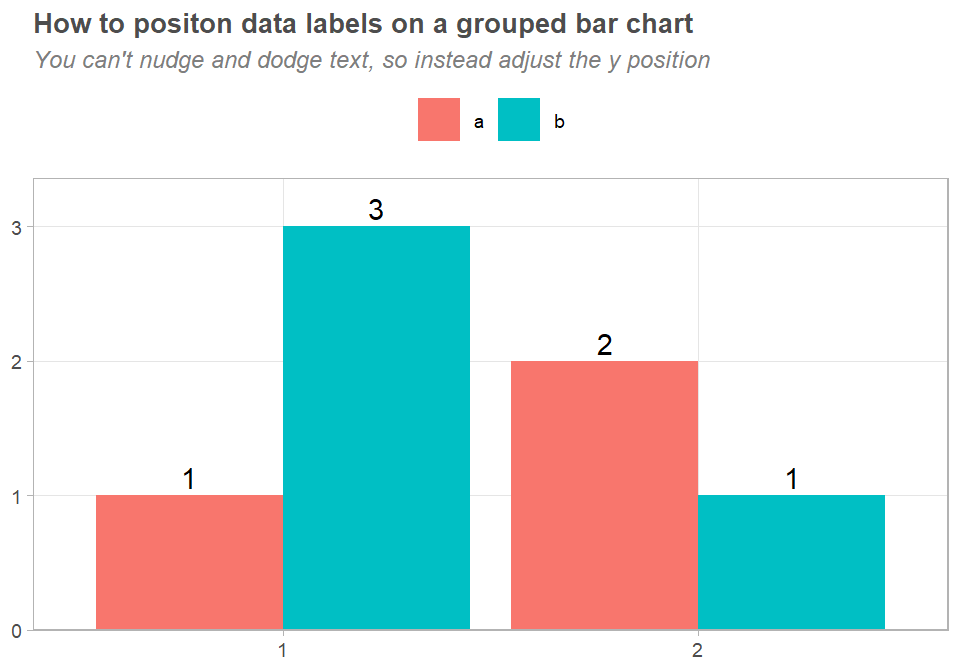

```r
ggplot(data=df, aes(x, y, group=grp)) +
  geom_col(aes(fill=grp), position=position_dodge()) +
  geom_text(
    aes(label=y, y=y + 0.05),
    position=position_dodge(0.9),
    vjust=0
  )  +
  scale_y_continuous(expand=expansion(mult=c(0,.1))) +
  theme(legend.position="top") +
  labs(title="How to positon data labels on a grouped bar chart",
       subtitle="You can't nudge and dodge text, so instead adjust the y position",
       x=NULL, y=NULL)
```

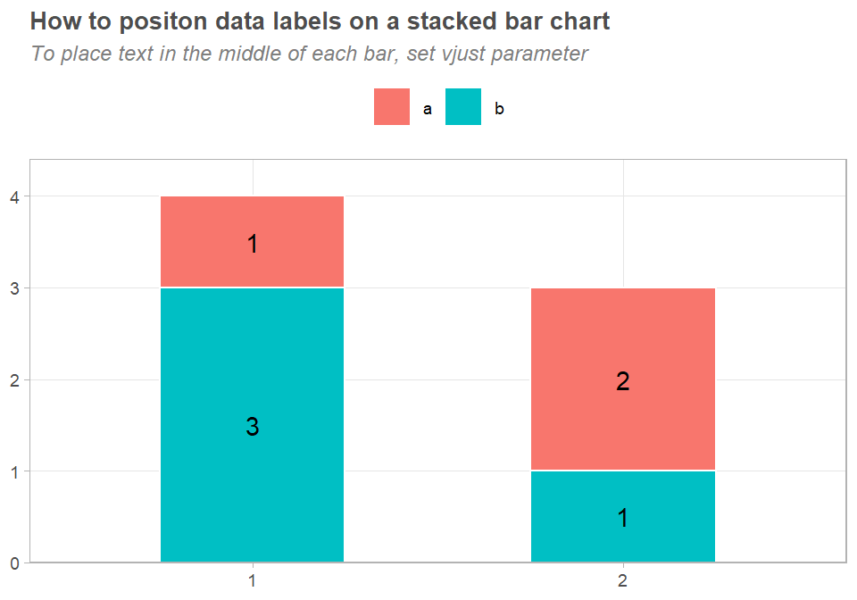

```r
ggplot(data=df, aes(x, y, group=grp)) +
  geom_col(aes(fill=grp), color="white", width=.5) +
  geom_text(aes(label=y), position=position_stack(vjust=0.5))  +
  scale_y_continuous(expand=expansion(mult=c(0,.1))) +
  theme(legend.position="top") +
  labs(title="How to positon data labels on a stacked bar chart",
       subtitle="To place text in the middle of each bar, set vjust parameter",
       x=NULL, y=NULL)
```

### 6.6.3 geom_text() basics

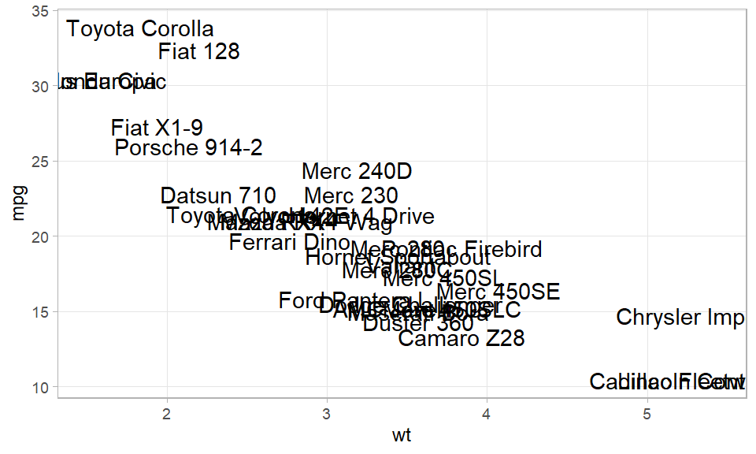

```r
p <- ggplot(mtcars, aes(wt, mpg, label=rownames(mtcars)))

p + geom_text()
```

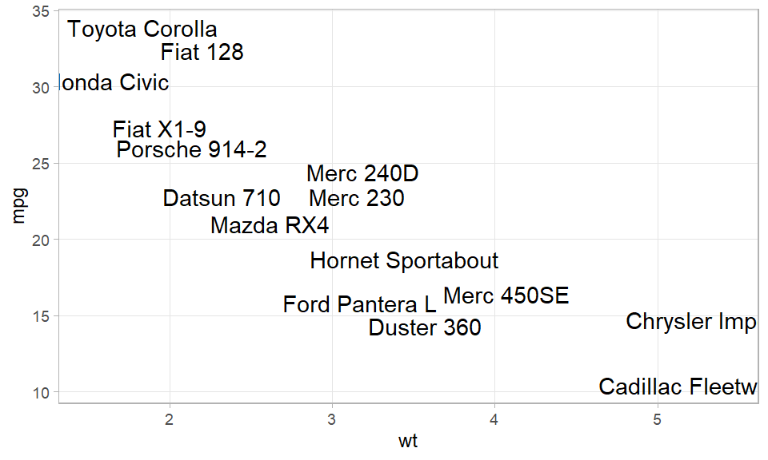

```r
p + geom_text(check_overlap=TRUE) # Avoid overlaps
```

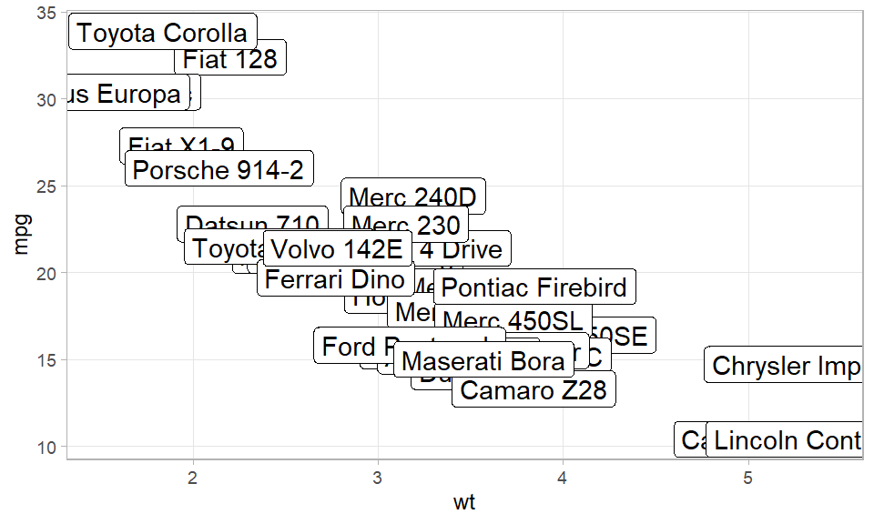

```r
p + geom_label() # Labels with background
```

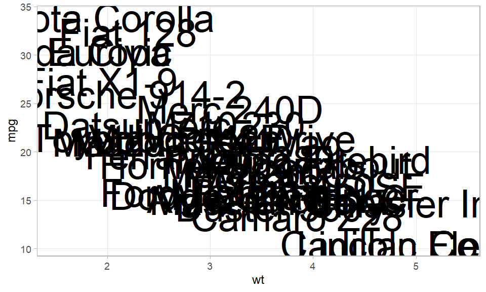

```r
p + geom_text(size=10) # Change size of the label
```

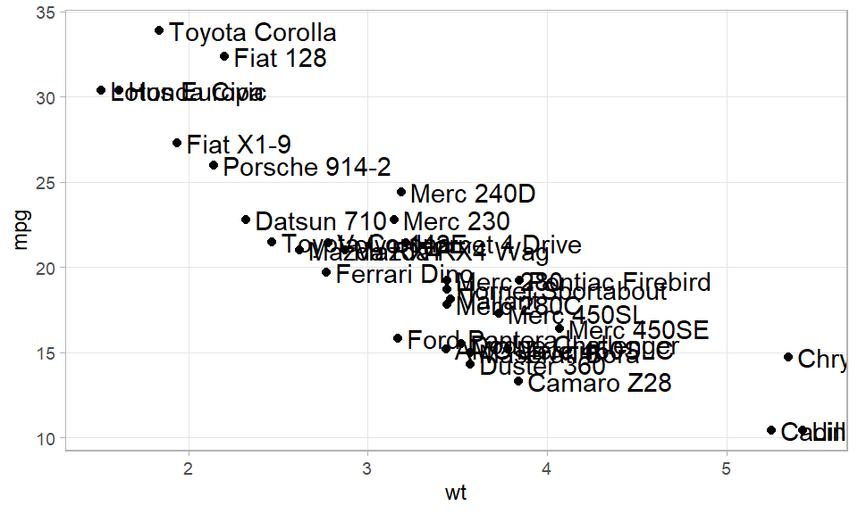

```r
# Position data labels ==========================
p +
  geom_point() +
  geom_text(hjust=0, nudge_x=0.05)
```

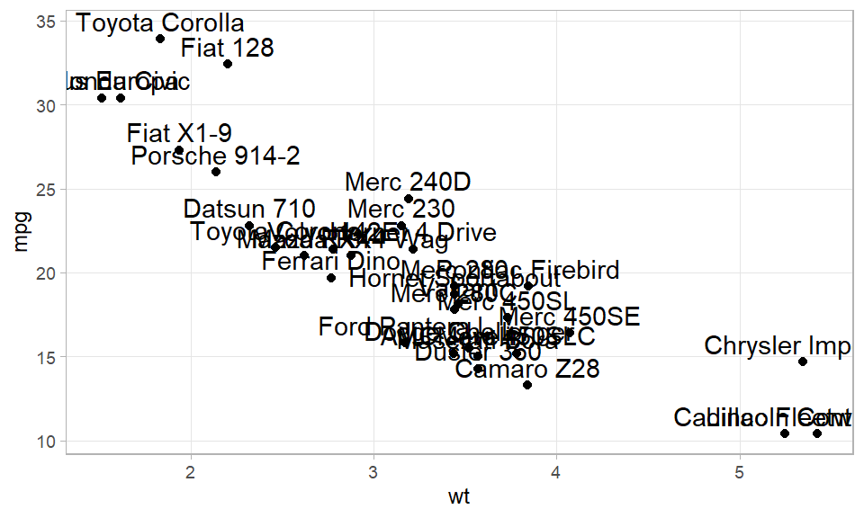

```r
p +
  geom_point() +
  geom_text(vjust=0, nudge_y=0.5)
```

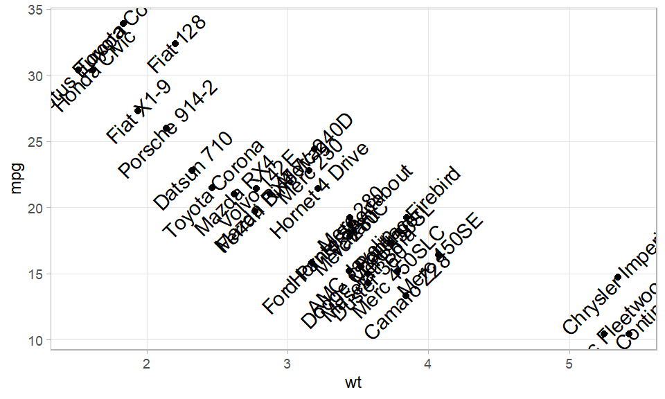

```r
p +
  geom_point() +
  geom_text(angle=45)
```

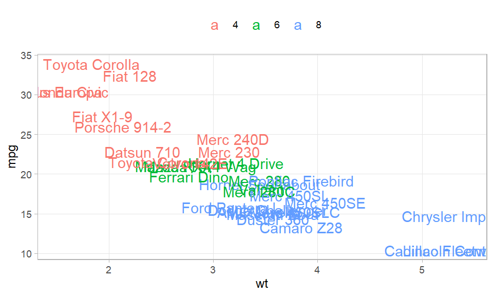

```r
# Add aesthetic mappings
p + geom_text(aes(colour=factor(cyl)))
```

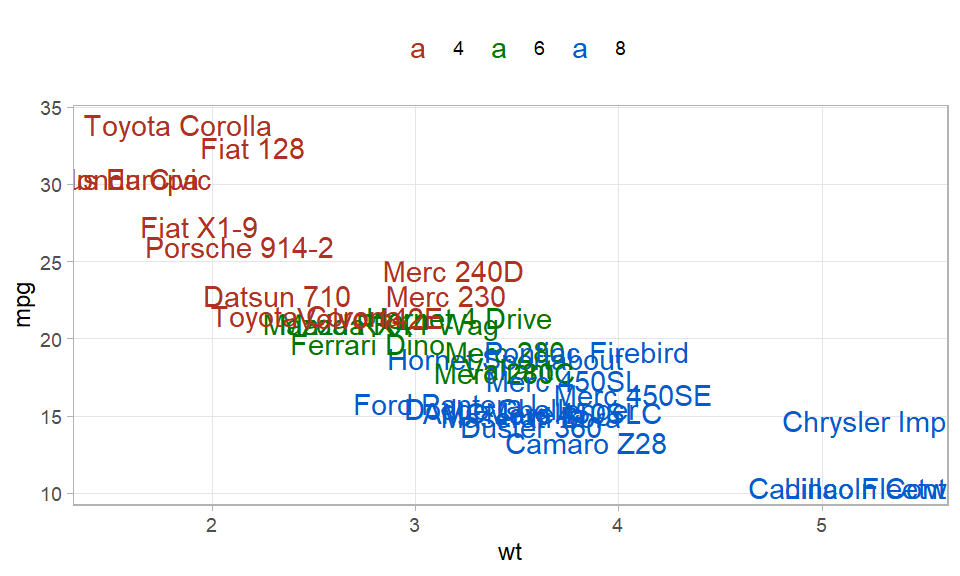

```r
p + geom_text(aes(colour=factor(cyl))) + scale_colour_discrete(l=40)
```

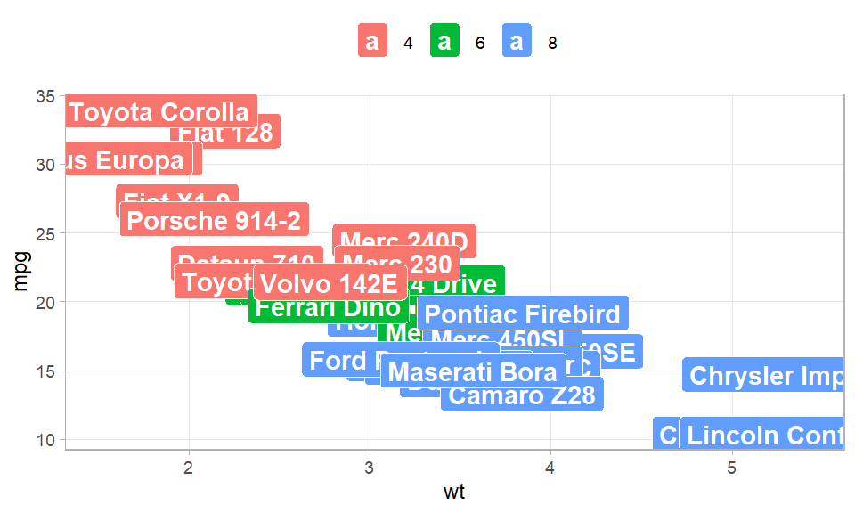

```r
p + geom_label(aes(fill=factor(cyl)), colour="white", fontface="bold")
```

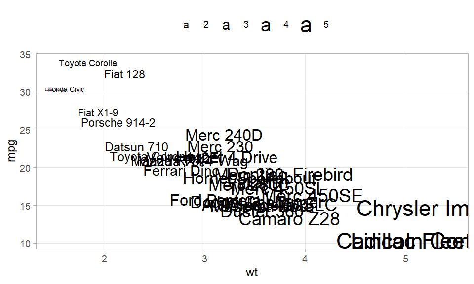

```r
p + geom_text(aes(size=wt))
```

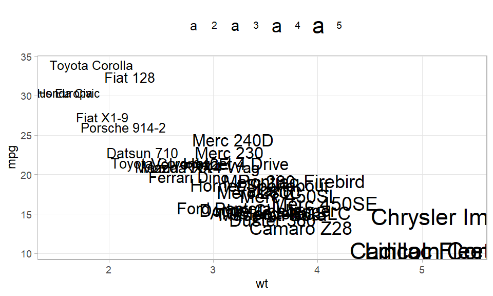

```r
# Scale height of text, rather than sqrt(height)
p +
  geom_text(aes(size=wt)) +
  scale_radius(range=c(3,6))
```

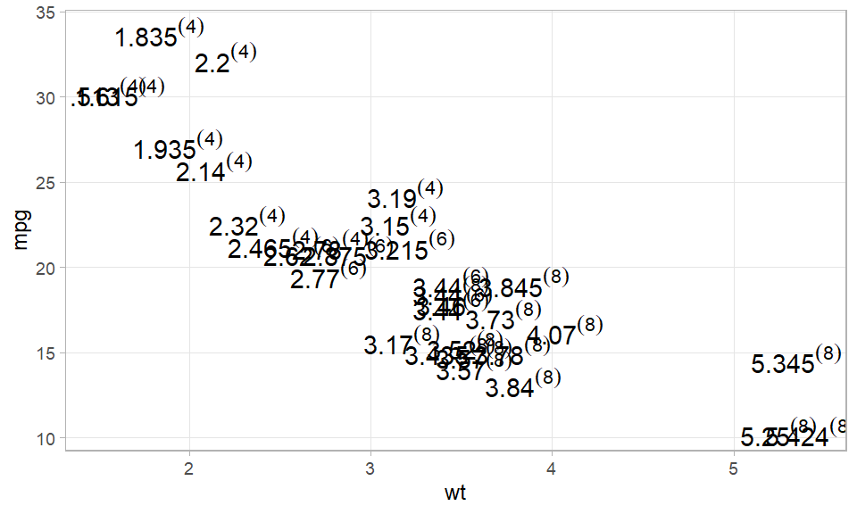

```r
# You can display expressions by setting parse=TRUE.  The
# details of the display are described in ?plotmath, but note that
# geom_text uses strings, not expressions.
p +
  geom_text(
    aes(label=paste(wt, "^(", cyl, ")", sep="")),
    parse=TRUE
  )
```

## 6.7 Annotations

[ggplot2 book](https://ggplot2-book.org/annotations.html#annotations)

- `geom_text()` and `geom_label()` to add text.
- `geom_rect()` to highlight interesting rectangular regions of the plot.

[Add straight lines to a plot](http://www.sthda.com/english/wiki/ggplot2-add-straight-lines-to-a-plot-horizontal-vertical-and-regression-lines):

- `geom_line()`, `geom_path()` and `geom_segment()` to add lines. Including an arrow parameter, which allows you to place an arrowhead on the line.
- `geom_vline()`, `geom_hline()` and `geom_abline()` allow you to add reference lines (sometimes called rules), that span the full range of the plot.

Typically, you can either put annotations in the foreground (using alpha if needed so you can still see the data), or in the background. With the default background, a thick white line makes a useful reference: it’s easy to see but it doesn’t jump out at you.

```r
presidential <- subset(presidential, start > economics$date[1] & start <= max(economics$date))
```

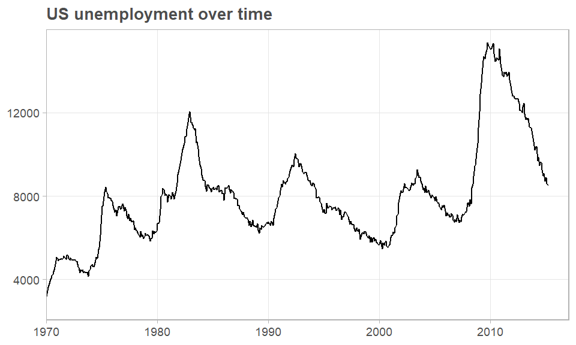

```r
ggplot(economics, aes(date, unemploy)) +
  geom_line() +
  scale_x_date(expand=c(0,0), date_breaks="10 years",
               limits=c(as_date("1970-1-1"),max(presidential$end)),
               labels=scales::label_date("%Y")) +
  labs(title="US unemployment over time", y=NULL, x=NULL)
```

One useful way to annotate this plot is to use shading to indicate which president was in power at the time.  
Notice that there is little new here: for the most part, annotating plots in `ggplot2` is a straightforward manipulation of existing geoms. There is one special thing to note in this code: the use of `-Inf` and `Inf` as positions. These refer to the top and bottom (or left and right) limits of the plot.

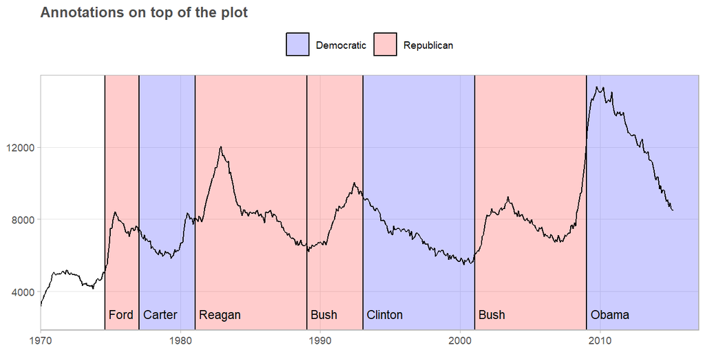

```r
economics |> na.omit() |> ggplot() +
  # Shading:
  geom_rect(
    data=presidential,
    aes(xmin=start, xmax=end, fill=party),
    ymin=-Inf, ymax=Inf,
    alpha=0.2, color="black"
  ) +
  geom_text(
    data=presidential,
    aes(x=start, y=2500, label=name),
    size=3, vjust=0, hjust=0, nudge_x=100
  ) +
  theme(legend.position="top") +
  geom_line(aes(date, unemploy)) +
  scale_fill_manual(values=c("blue", "red")) +
  scale_x_date(expand=c(0,0), date_breaks="10 years", limits=c(as_date("1970-1-1"),NA),
               labels=scales::label_date("%Y")) +
  labs(title="Annotations on top of the plot", x=NULL, y=NULL)
```

This technique can be applied in other ways too. For instance, you can use it to add a single annotation to a plot.

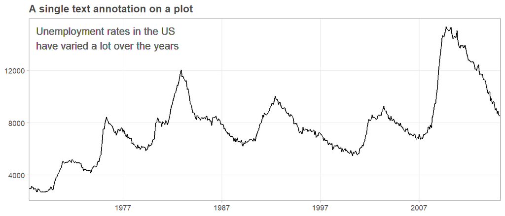

```r
annotation <- "Unemployment rates in the US\nhave varied a lot over the years"
# paste(strwrap("Unemployment rates in the US have varied a lot over the years", 40), collapse="\n")

economics |>
  ggplot(aes(x=date, y=unemploy)) +
  geom_line() +
  geom_text(
    aes(x=min(economics$date), y=max(economics$unemploy), label=annotation),
    hjust=-0.05, vjust=1, size=3.5, color="gray40"
  ) +
  scale_x_date(expand=c(0,0), date_breaks="10 years",
               labels=scales::label_date("%Y")) +
  labs(title="A single text annotation on a plot", y=NULL, x=NULL)
```

A common form of annotation is to highlight a subset of points by drawing larger points in a different color underneath the main data set. To highlight vehicles manufactured by Subaru you could use this to create the basic plot:

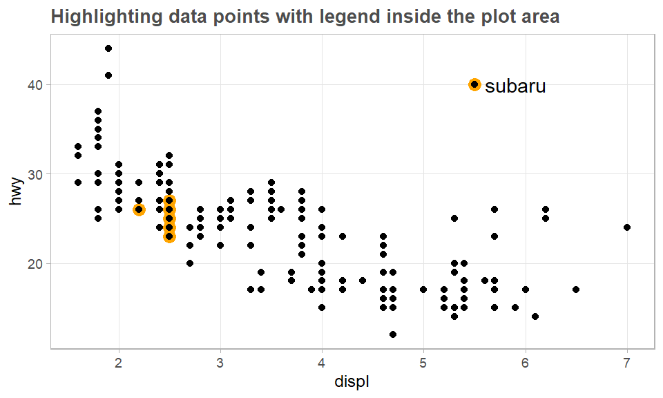

```r
p <- ggplot(mpg, aes(displ, hwy)) +
  geom_point(
    data=filter(mpg, manufacturer == "subaru"),
    colour="orange",
    size=3
  ) +
  geom_point()


p +
  annotate(geom="point", x=5.5, y=40, colour="orange", size=3) +
  annotate(geom="point", x=5.5, y=40) +
  annotate(geom="text",  x=5.6, y=40, label="subaru", hjust="left") +
  labs(title="Highlighting data points with legend inside the plot area")
```

This approach has the advantage of creating a label inside the plot region, but the drawback is that the label is distant from the points it picks out (otherwise the orange and black dot adjacent to the label might be confused for real data).

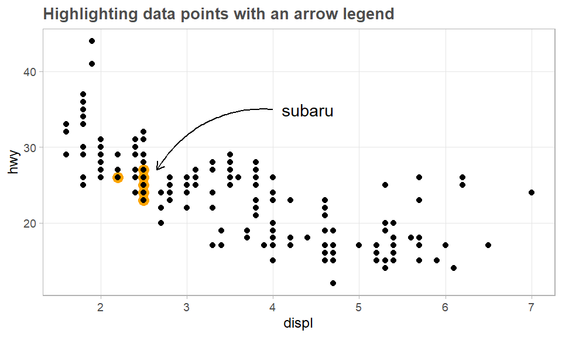

```r
p +
  annotate(
    geom="curve", x=4, y=35, xend=2.65, yend=27,
    curvature=.3, arrow=arrow(length=unit(2, "mm"))
  ) +
  annotate(geom="text", x=4.1, y=35, label="subaru", hjust="left") +
  labs(title="Highlighting data points with an arrow legend")
```

The `directlabels` package, by Toby Dylan Hocking, provides a number of tools to make annotations more automated. See the [directlabels website](http://directlabels.r-forge.r-project.org), for other techniques.

Another take on this idea comes from the [ggforce package](https://github.com/thomasp85/ggforce) by Thomas Lin Pedersen. The `ggforce` package contains a lot of useful tools to extend `ggplot2` functionality, including functions such as `geom_mark_ellipse()` that overlays a plot with circular “highlight” marks.

**GGHIGHLIGHT**

A third approach to direct labelling is provided in the [gghighlight package](https://github.com/yutannihilation/gghighlight) by Hiroaki Yutani. It is useful for highlighting points or lines (or indeed a variety of different geoms) within a plot, particularly for longitudinal data. This package is also useful when you want each facet of a plot to display data from a single group, with the complete data set plotted unobtrusively in each panel to aid visual comparison.

You may want the reader to compare groups across facets. In the plot below it is easy to see the relationship within each facet, but the subtle differences across facets do not pop out:

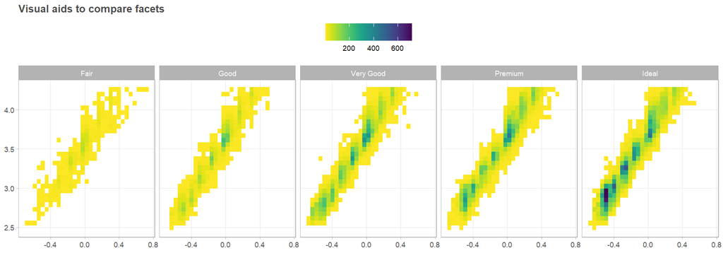

```r
ggplot(diamonds, aes(log10(carat), log10(price))) +
  geom_bin2d() +
  facet_wrap(vars(cut), nrow=1) +
  viridis::scale_fill_viridis(direction=-1, option="D") +
  labs(title="Visual aids to compare facets", y=NULL, x=NULL)
```

It is much easier to see these subtle differences if we add a reference line. In this plot, each facet displays the data for one category against the same regression line. This makes it easier to compare the facets to each other because there is shared reference line to assist the visual comparison.

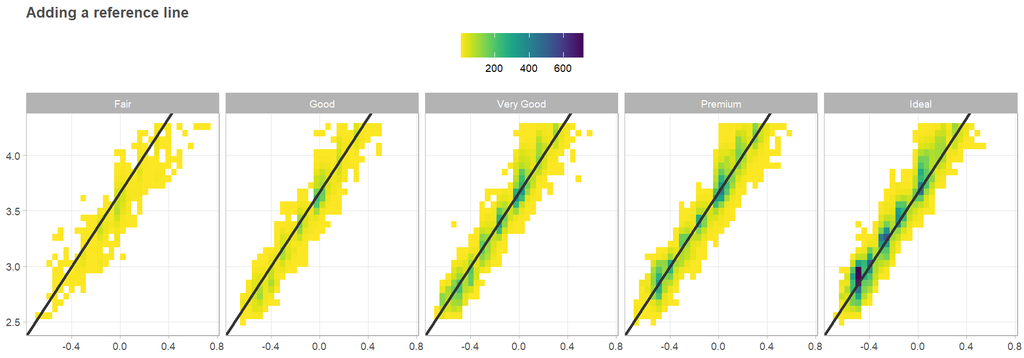

```r
mod_coef <- coef(lm(log10(price) ~ log10(carat), data=diamonds))
ggplot(diamonds, aes(log10(carat), log10(price))) +
  geom_bin2d() +
  geom_abline(intercept=mod_coef[1], slope=mod_coef[2],
              colour="grey20", size=1) +
  facet_wrap(vars(cut), nrow=1) +
  viridis::scale_fill_viridis(direction=-1, option="D")  +
  labs(title="Adding a reference line", y=NULL, x=NULL)
```

# 7 OTHER TRICKS

## 7.1 Reference df inside ggplot call

Use the dot `.` to reference the df inside the ggplot call (even if it is modified).

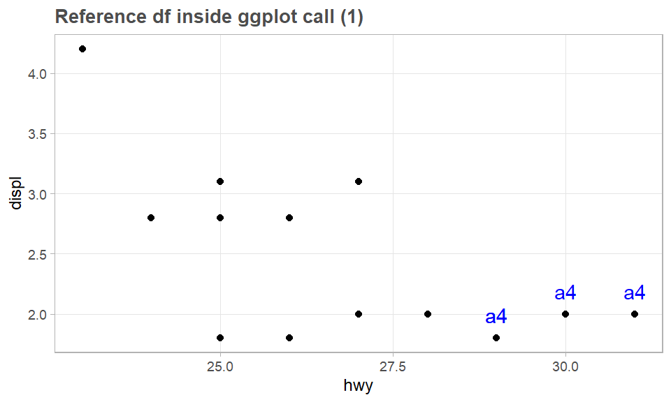

```r
mpg |>
  filter(manufacturer == 'audi') |>
  ggplot(aes(x = hwy, y = displ, label = model)) +
  geom_point() +
  geom_text(data = . %>% filter(hwy > 28), vjust=-1, color="blue") +
  labs(title = "Reference df inside ggplot call (1)")
```

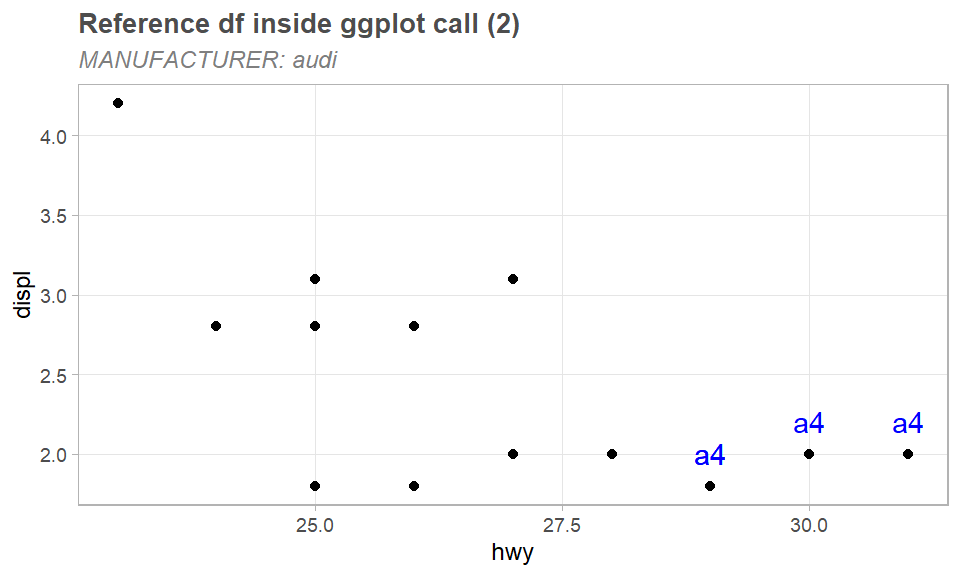

```r
mpg %>%
  filter(manufacturer == 'audi') %>% {
    ggplot(., aes(x = hwy, y = displ, label = model)) +
      geom_point() +
      geom_text(data = . %>% filter(hwy > 28), vjust=-1, color="blue") +
      labs(
        title = "Reference df inside ggplot call (2)",
        subtitle = glue::glue("MANUFACTURER: {unique(.$manufacturer)}"),
      )
  }
```

## 7.2 Switch data for a plot

Minimize repetitive ggplot function by switching data.

Instead of writing ggplot commands, again and again, use `%+%` to override the current data with the new data.

**Warning**: For `%+%` to work, make sure the column names of the new data matches the column names of the dataset being replaced.

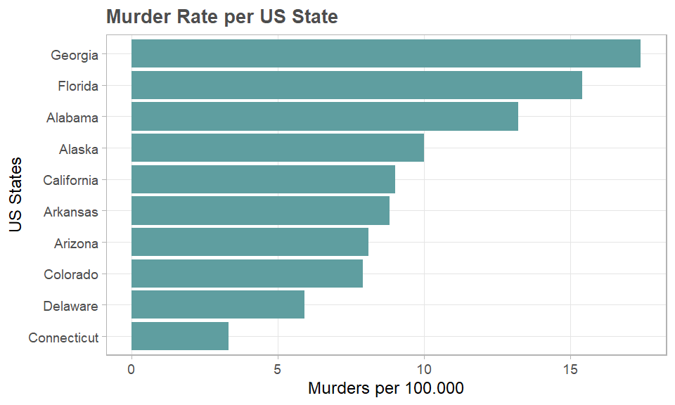

```r
(plot <-
   as_tibble(USArrests, rownames="States") |>
   head(10) |>
   ggplot(aes(y=fct_reorder(States, Murder, .desc=FALSE), x=Murder)) +
   geom_col(fill="cadetblue") +
   labs(
     y="US States",
     x="Murders per 100.000",
     title="Murder Rate per US State"
   ))
```

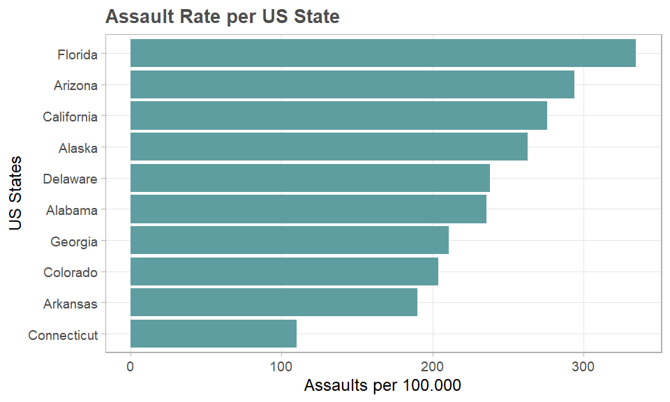

```r
plot %+% (
  as_tibble(USArrests, rownames="States")[,c(1,3)]  |>
    head(10) |>
    rename(Murder=Assault) # renames the variable just for the plotting
) +
  labs(
    y="US States",
    x="Assaults per 100.000",        # but specifies the title of the visual on the plot
    title="Assault Rate per US State"
  )
```

## 7.3 Figure size in Rmarkdown

Let’s look at some ways to size a figure with RMarkdown.

**Define size in YAML header:** We can define the size of figures globally in the YAML part, like this for example.

```
---
title: "My Document"
output: html_document:
fig_width: 7.5
fig_height: 4.5
---
```

**Define figure size as global chunk option**

```
knitr::opts_chunk$set(fig.width=7.5, fig.height=4.5)
```

**Chunk options**: We can set the chunk options for each chunk. With `fig.height` and `fig.width` we can define the size. The sizes are set in inches.

```
'''{r fig.height=3, fig.width=5}
ggplot(mpg, aes(displ, hwy)) +
  geom_point(
    data=filter(mpg, manufacturer == "subaru"),
    colour="orange",
    size=3
  ) +
  geom_point()
'''
```

For a plot of different size, simply change the numbers: `{r fig2, fig.height=3, fig.width=3, fig.align="center"}`.

```
'''{r fig.height=3, fig.width=3, fig.align="center"}
ggplot(mpg, aes(displ, hwy)) +
  geom_point(
    data=filter(mpg, manufacturer == "subaru"),
    colour="orange",
    size=3
  ) +
  geom_point()
'''
```

Alternatively, you may change the aspect ratio of the image (the ratio of height/width): `{r fig3, fig.width=5, fig.asp=.62}`. Note that the aspect ratio is based on the `fig.width` specified.

```
'''{r fig.width=8, fig.asp=.6}
ggplot(mpg, aes(displ, hwy)) +
  geom_point(
    data=filter(mpg, manufacturer == "subaru"),
    colour="orange",
    size=3
  ) +
  geom_point()
'''
```

## 7.4 Save plots

`ggsave()` function allows users to save high-resolution images for publications, presentations. The ggsave function has features to adjust image size, define the resolution and adjusting the image background to be transparent or not, and flexibility to choose different file extensions.

```
ggsave(
  filename="trial.png",
  device=png(),
  path="plots/",
  scale=1,
  width=5,
  height=8,
  units="in",
  dpi=600,
  limitsize=TRUE,
  bg="transparent"
)
```

## 7.5 Suppress warnings

**Do you need to suppress warnings or do you need to put `na.rm=TRUE` in the `geom_*()` call?**

You need to `suppressWarnings()` around the `print()` call, not the creation of the `ggplot()` object:

```
suppressWarnings(
  print(
    ggplot(mydf, aes(x=species)) +
      stat_bin() +
      geom_text(data=labs, aes(x=species, y=value,
                                 label=value, vjust=-0.5)) +
      facet_wrap(~ lvl)
  )
)
```

The reason for the behaviour is that the warnings are only generated when the plot is actually drawn, not when the object representing the plot is created. R will auto print during interactive usage, so whilst `suppressWarnings(plt)` doesn’t work because, in effect, you are calling `print(suppressWarnings(plt))`, whereas `suppressWarnings(print(plt))` does work because `suppressWarnings()` can capture the warnings arising from the `print()` call.